# Interpreting breakpoint fits

## An idea

Look specifically at the predictions from the best-fitting breakpoint model. (This model could be: no breakpoints + no slope, no breakpoints + slope, n breakpoints + no slope, n breakpoints + slopes).

There’s some qualitative behaviors we can extract from the predictions (that come logically but less elegantly from the parameters, etc).

Two axes:

1. **Monotonic or squiggly:** Monotonic can encompass all linear (no-break) models, *and* any models with breakpoints that do not result in changes in direction.
2. **Net change or net 0:** The ratio of the end:beginning *prediction*.

The 2x2:

1. **Monotonic** and **net change**: This would be some kind of overall trend, either steady (probably would show as a 1-segment linear model), possibly accelerating or decelerating across the timeseries (would show as multiple segments with slopes), or even as a series of abrupt changes (would show as multiple segments with *no* slopes).
2. **Monotonic** and **no net change**: This can basically only be accomplished as a one-segment linear model with a slope very close to 0. (Theoretically you could have many verrrrry gently sloping segments, but I doubt we have the statistical power such that something like that would emerge as the best fit). I think this is either very stable or *so* variable that not even many breakpoints can adequately capture the variability.
3. **Turnpoints** and **net change**: The TS changes direction at least once, and ends up somewhere other than where it started. This *must* involve breakpoints. At the moment I think I have less confidence in such an outcome as evidence of systematic directional change - it seems potentially sensitive to, if we stopped surveying 5 years earlier, would we have a totally different trend?
4. **Turnpoints** and **no net change**: Qualitatively different from, monotonic and no net change….Again, I am not sure how confident I am in this as a signal of any kind of regulation/buffering. But maybe.

### Illustration via a few real datasets

[output not shown]

[output cut: 67 more lines]

[output not shown]

### Grouped by turns/no

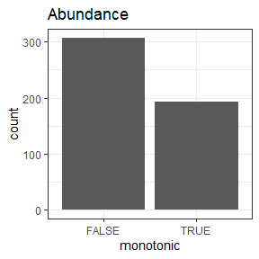

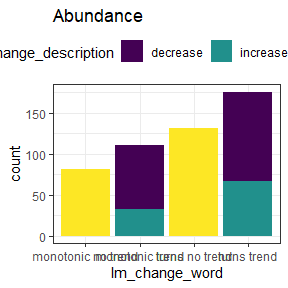

```
## # A tibble: 6 x 7
##   currency monotonic n_mono_or_turns lm_change_descr~ n_lm_change_des~
##   <chr>    <lgl>               <int> <chr>                       <int>
## 1 abundan~ FALSE                 307 decrease                      109
## 2 abundan~ FALSE                 307 increase                       67
## 3 abundan~ FALSE                 307 no trend                      131
## 4 abundan~ TRUE                  193 decrease                       78
## 5 abundan~ TRUE                  193 increase                       33
## 6 abundan~ TRUE                  193 no trend                       82
## # ... with 2 more variables: lm_change_word <chr>, n_trend_or_no <int>
```

### Grouped by trend

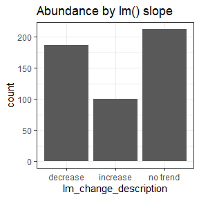

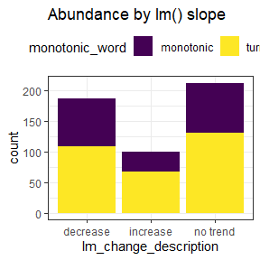

```
## # A tibble: 6 x 5
##   currency  lm_change_description n_trend_type monotonic n_monotonic_trend
##   <chr>     <chr>                        <int> <lgl>                 <int>
## 1 abundance decrease                       187 FALSE                   109
## 2 abundance decrease                       187 TRUE                     78
## 3 abundance increase                       100 FALSE                    67
## 4 abundance increase                       100 TRUE                     33
## 5 abundance no trend                       213 FALSE                   131
## 6 abundance no trend                       213 TRUE                     82
```

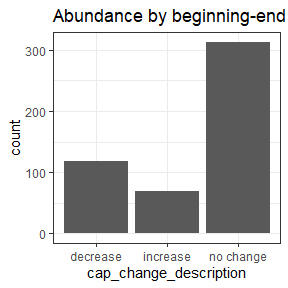

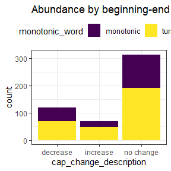

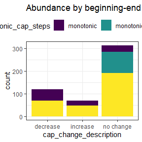

```
## # A tibble: 6 x 5
##   currency  cap_change_description n_trend_type monotonic n_monotonic_trend
##   <chr>     <chr>                         <int> <lgl>                 <int>
## 1 abundance decrease                        118 FALSE                    69
## 2 abundance decrease                        118 TRUE                     49
## 3 abundance increase                         69 FALSE                    48
## 4 abundance increase                         69 TRUE                     21
## 5 abundance no change                       313 FALSE                   190
## 6 abundance no change                       313 TRUE                    123
```

## Distributions of slopes

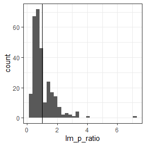

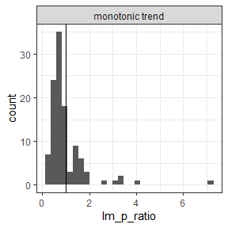

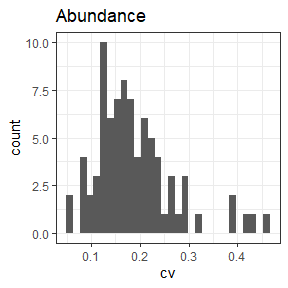